# Maintaining Sense of Purpose Following Health Adversity in Older Adulthood: A Propensity Score Matching Examination

Patrick L Hill

Emorie D Beck

Joshua J Jackson

#Workspace ##Packages

```r
library(survey)
library(mi)
library(psych)
library(MatchIt)
library(brms)
library(MuMIn)
library(googlesheets)
library(parallel)
library(gridExtra)
library(knitr)
library(kableExtra)
library(stargazer)
library(plyr)
library(stringr)
library(haven)
library(tidyverse)

data_path <- "~/Box/network/other projects/health events"
res_path <- "~/Box/network/other projects/purpose and health events"
```

# Data

## Load Raw Data

```r
# load google sheet containing variable names, recoding, etc #
dat <- sprintf("%s/HRS_codebook.xlsx", res_path) %>%
  readxl::read_xlsx(.) %>%
  filter(Include == "Yes") %>%
  mutate(Item = ifelse(Dataset == "Rand", str_to_lower(Item), str_to_upper(Item)),
         Item = str_replace_all(Item, "[[:space:]]", ""),
         new_name = str_replace_all(new_name, "[[:space:]]", ""))

# load(sprintf("%s/data/raw_data.RData", data_path))
```

```r
dem.old <- (dat %>% filter(Dataset == "Rand" & Type == "demographic"))$Item
dem.new <- (dat %>% filter(Dataset == "Rand" & Type == "demographic"))$new_name

old.names <- (dat %>% filter(Dataset == "Rand" & Type != "demographic"))$Item
new.names <- (dat %>% filter(Dataset == "Rand" & Type != "demographic"))$new_name

hrs.rand <- haven::read_sav(sprintf("%s/data/rndhrs_p.sav", data_path)) %>%
  tbl_df() %>%
  select(one_of(dem.old), one_of(old.names)) %>%
  setNames(c(dem.new, new.names))

match.dat <- hrs.rand %>%
  gather(key = new_name, value = value, -PROC_CID, -DemDOB, -DemDeath, -DemGender,
         -DemRace_all.1992, -DemRace_hispan.1992) %>%
  full_join(dat %>% filter(Dataset == "Rand" & Type == "matching") %>%
              select(new_name, Wave, Type, rule, rev_code, mini, maxi, recode)) %>%
  filter(is.na(DemDeath) == T | DemDeath > 2006)

old.names <- (dat %>% filter(Dataset == "PLB"))$Item
new.names <- (dat %>% filter(Dataset == "PLB"))$new_name


read_fun <- function(year) {
  read_da <- function(da, dct, year){
    print(paste(da, dct, year, sep = " "))
    data.file <- sprintf("%s/data/%s/%s", data_path, year, da)
    # Set path to the dictionary file "*.DCT"
    dict.file <- sprintf("%s/data/%s/%s", data_path, year, dct)
    # Read the dictionary file
    df.dict <- read.table(dict.file, skip = 1, fill = TRUE, stringsAsFactors = FALSE)
    # Set column names for dictionary dataframe
    colnames(df.dict) <- c("col.num","col.type","col.name","col.width","col.lbl")
    # Remove last row which only contains a closing }
    row <- which(df.dict$col.name == "HHID")
    df.dict <- df.dict[-nrow(df.dict),]
    if(row == 2){df.dict <- df.dict[-1,]}
    # Extract numeric value from column width field
    df.dict$col.width <- as.integer(sapply(df.dict$col.width, gsub, pattern = "[^0-9\\.]", replacement = ""))
    # Convert column types to format to be used with read_fwf function
    df.dict$col.type <- sapply(df.dict$col.type, function(x) ifelse(x %in% c("int","byte","long"), "i", ifelse(x == "float", "n", ifelse(x == "double", "d", "c"))))
    # Read the data file into a dataframe
    df <- read_fwf(file = data.file, fwf_widths(widths = df.dict$col.width, col_names = df.dict$col.name), col_types = paste(df.dict$col.type, collapse = ""))
    # Add column labels to headers
    attributes(df)$variable.labels <- df.dict$col.lbl
    if(all(c("PN", "HHID") %in% colnames(df))){
      df <- df %>%
      mutate(hhidpn = 1000*as.numeric(HHID) + as.numeric(PN)) %>%
      select(-HHID, -PN) %>%
      gather(key = item, value = value, -hhidpn, na.rm = T)
    } else {df <- NA}
    return(df)
  }
    # Set path to the data file "*.DA"
  files <- list.files(sprintf("%s/data/%s", data_path, year))
  df2 <- tibble(
    da = files[grepl(".da",  files) | grepl(".DA", files)],
    dct = files[grepl(".dct", files) | grepl(".DCT", files)]
  ) %>%
    mutate(data = map2(da, dct, possibly(~read_da(.x, .y, year), NA_real_))) %>%
    filter(!is.na(data)) %>%
    unnest(data) %>%
    select(-da, -dct)
}

hrs.paq <- tibble(
  Year = seq(1992,2016,2),
  new.wave = c(rep(NA,7), rep(seq(1,3,1),each=2))
) %>%
  mutate(data = map(Year, read_fun)) %>%
  unnest(data, .drop = T) %>%
  rename(PROC_CID = hhidpn) %>%
  filter(item %in% old.names) %>%
  mutate(new_name = mapvalues(item, old.names, new.names)) %>%
  full_join(dat %>% filter(Dataset == "PLB") %>%
              select(new_name, Wave, Type, rule, rev_code, mini, maxi, recode)) %>%
  mutate_at(vars(value, mini, maxi), funs(as.numeric)) %>%
  group_by(new_name) %>%
  mutate(value = ifelse(rev_code == 0 | is.na(rev_code) == T, value,
                        reverse.code(-1, value, mini = mini[1], maxi = maxi[1]))) %>%
  ungroup() %>%
  select(-rev_code, -mini, -maxi)

save(match.dat, file = sprintf("%s/data/match_dat.Rdata", data_path))
save(hrs.paq, file = sprintf("%s/data/hrs.paq.Rdata", data_path))
```

## Outcome Data

```r
cesd <- hrs.rand %>% select(PROC_CID, contains("CESD")) %>%
  mutate_all(as.numeric) %>%
  gather(key = item, value = value, -PROC_CID, na.rm = T) %>%
  separate(item, c("Trait", "cat"), sep = "_") %>%
  separate(cat, c("item", "Year"), sep = "[.]") %>%
  separate(item, c("scrap", "item"), -1) %>%
  select(-scrap) %>%
  mutate(new.wave = mapvalues(Year, seq(1992,2016,2),
          c(rep(NA,7), rep(seq(1,3,1),each=2)))) %>%
  filter(Year %in% seq(2006,2016,2)) %>%
  group_by(PROC_CID) %>%
  mutate(Year = as.numeric(Year), fy = min(Year, na.rm = T),
         new.wave = as.numeric(new.wave),
         new.wave = ifelse(!(fy %in% c(2006,2008)),
             new.wave-min(new.wave) + 1, new.wave)) %>%
  select(PROC_CID, new.wave, Trait, item, value, fy)

pers.long <- hrs.paq %>%
  filter(Type == "outcome" & !is.na(value)) %>%
  select(-Year, -item, -recode) %>%
  separate(new_name, c("item", "Year"), sep = "[.]") %>%
  group_by(PROC_CID) %>%
  mutate(fy = as.numeric(min(Year, na.rm = T)),
         new.wave = ifelse(!(fy %in% c(2006,2008)),
             new.wave-min(new.wave) + 1, new.wave)) %>%
  select(-Year) %>%
  separate(item, c("cat", "item"), sep = "_") %>%
  separate(item, c("Trait", "item"), -1) %>%
  select(PROC_CID, new.wave, Trait, item, value, fy) %>%
  full_join(cesd) %>%
  group_by(PROC_CID, new.wave, Trait, item, fy) %>%
  summarize(value = mean(value, na.rm = T)) %>%
  left_join(hrs.rand %>% select(PROC_CID, DemDOB, DemGender)) %>%
  group_by(PROC_CID, Trait, item) %>%
  mutate(na = sum(!is.na(value))) %>%
  ungroup() %>%
  # recode gender & center age at first BFI wave (2005)
   # male = 1, female = 2 --> male = 1, female = 0
  mutate(sex12 = mapvalues(DemGender, c(1,2), c(1,0), warn_missing = F),
         sex.c = as.numeric(scale(sex12, center = T, scale = F)),
         age = as.numeric(fy)-DemDOB,
         age.c = age - mean(age, na.rm = T),
         age.c2 = age.c^2, #agec2 = agec^2,
         age.c3 = age.c^3) #agec3 = agec^3

pers.wide <- pers.long %>%
  filter(na > 1) %>%
  mutate(new.wave = paste("T", new.wave, sep = "")) %>%
  unite(temp, new.wave, item, sep = ".") %>%
  spread(key = temp, value = value)

pers.match <- pers.long %>%
  # filter(new.wave == 1) %>%
  group_by(PROC_CID, new.wave, Trait) %>%
  summarize(value = mean(value, na.rm = T)) %>%
  ungroup() %>%
  unite(Trait, Trait, new.wave, sep = "_") %>%
  # mutate(Trait = paste(Trait, "W1", sep = "_")) %>%
  spread(key = Trait, value = value)

pers.long <- pers.long %>%
  group_by(new.wave, Trait, PROC_CID, DemDOB, DemGender,
           sex12, sex.c, age, age.c, age.c2, age.c3) %>%
  summarise(value = mean(value, na.rm = T))
```

## Matching Data

### Combine and Reverse Code

```r
match.dat <- hrs.rand %>%
  gather(key = new_name, value = value, -PROC_CID, -DemDOB, -DemDeath, -DemGender,
         -DemRace_all.1992, -DemRace_hispan.1992) %>%
  full_join(dat %>% filter(Dataset == "Rand" & Type == "matching") %>%
              select(new_name, Wave, Type, rule, rev_code, mini, maxi, recode)) %>%
  #filter(is.na(DemDeath) == T | DemDeath < 2006) %>%
  mutate_at(vars(value, mini, maxi), funs(as.numeric)) %>%
  group_by(new_name) %>%
  mutate(value = ifelse(is.na(rev_code) | rev_code == 0, value,
                        reverse.code(-1, value, mini = mini[1], maxi = maxi[1]))) %>%
  ungroup() %>%
  select(-rev_code, -mini, -maxi) %>%
  full_join(hrs.paq %>%
    filter(Type == "matching" & !is.na(value)) %>%
    select(-Year, -Wave, -item)) %>%
  separate(new_name, c("item", "Year"), sep = "[.]") %>%
  filter(!is.na(value) & Year <= 2006)
```

### Recode

```r
match.dat <- match.dat %>%
  mutate(value = ifelse(item == "MarStat_rMarStat", mapvalues(value,
                    from = seq(1,8), to = c(rep(1,3), rep(2,3), 3, 0)), value),
         # value = ifelse(item %in% c("HBehVigAct_rHBehVigAct", "HBehModAct_rHBehModAct",
         #                            "HBehLightAct_rHBehLightAct") & value >= 3, 1, value),
         value = ifelse(item == "Religion_Religion", mapvalues(value, 1:5, c(1,1,2,0,2)), value),
         value = ifelse(grepl("^LE", item) == T, mapvalues(value, c(1,5), c(1,0)), value))
```

```r
Mode <- function(x) {
  ux <- unique(x)
  ux <- ux[!is.na(ux)]
  ux[which.max(tabulate(match(x, ux)))]
}

ceil_average <- function(x){
  ceiling(mean(x, na.rm = T))
}

sum_fun <- function(df, Rule){
  fun_call <- function(x, rule){
    switch(rule,
           average = mean(x, na.rm = T),
           mode = Mode(x)[1],
           sum = sum(x, na.rm = T),
           select = unique(x)[1],
           max = max(x, na.rm = T),
           min = min(x, na.rm = T),
           ceil_average = ceil_average(x))
  }
  df %>%
    group_by(PROC_CID, item, DemDOB, DemDeath, DemGender,
             DemRace_all.1992, DemRace_hispan.1992) %>%
    summarize(value = fun_call(value, Rule)) %>%
    mutate(value = ifelse(is.nan(value) == T, NA,
                 ifelse(is.infinite(value) == T, NA, value))) %>%
    ungroup()
}

match.dat.wide <- match.dat %>%
  filter(Type == "matching" & (DemDeath > 2006 | is.na(DemDeath))) %>%
  group_by(rule) %>%
  nest() %>%
  mutate(data = map2(data, rule, possibly(sum_fun, NA_real_))) %>%
  unnest(data, .drop = T) %>%
  separate(item, c("item", "scrap")) %>%
  group_by(rule) %>%
  nest() %>%
  mutate(data = map2(data, rule, possibly(sum_fun, NA_real_))) %>%
  unnest(data, .drop = T)  %>%
  group_by(PROC_CID) %>%
  mutate_at(vars(DemDOB:DemRace_hispan.1992), funs(max(., na.rm = T))) %>%
  mutate_at(vars(DemDOB:DemRace_hispan.1992), funs(ifelse(is.infinite(.) == T, NA_real_, .)))
match.dat.wide <- match.dat.wide %>%
  select(PROC_CID, item, value) %>% # get rid of the rule variables
  spread(key = item, value = value) %>% # change to wide format
  full_join(unique(match.dat.wide %>% select(PROC_CID, DemDOB:DemRace_hispan.1992))) %>%
  mutate(DemRace = DemRace_all.1992,
         DemRace = ifelse(DemRace_hispan.1992 == 1, 3, DemRace)) %>%
  select(-DemRace_hispan.1992, -DemRace_all.1992)

match.dat.wide <- match.dat.wide %>%
  full_join(pers.match)
```

## Grouping Data

```r
new.names <- (dat %>% filter(Dataset == "Rand" & Type == "grouping"))$new_name
years <- seq(1992,2016,2)
new.waves <-  c(rep(NA,7), rep(seq(1,3,1),each=2))

grouping.dat <- hrs.rand %>%
  select(PROC_CID:DemDeath, one_of(new.names)) %>%
  gather(key = new_name, value = value, -PROC_CID, -DemDOB, -DemDeath, na.rm = T) %>%
  full_join(dat %>% filter(Dataset == "Rand" & Type == "grouping") %>%
              select(new_name, Wave, Type, rule, rev_code, mini, maxi, recode)) %>%
  filter((is.na(DemDeath) == T | DemDeath > 2006) & Type == "grouping") %>%
  separate(new_name, c("item", "Year"), sep = "[.]") %>%
  mutate(new.wave = mapvalues(Year, years, new.waves),
         value = ifelse(value > 1, 1, value))

pre2006 <- grouping.dat %>%
  filter(Year <= 2006 & grepl("Ever", item)) %>%
  separate(item, c("Event", "item"), sep = "_") %>%
  group_by(PROC_CID, Event) %>%
  summarize(remove = sum(value, na.rm = T),
            remove = ifelse(remove >=1,1,remove)) %>%
  filter(remove > 0)

grouping.long <- grouping.dat %>%
  # filter(pre2006 == 0 & Year >= 2006) %>%
  filter(!is.na(new.wave)) %>%
  separate(item, c("Event", "item"), sep = "_") %>%
  group_by(PROC_CID, Event, new.wave) %>%
  summarize(value = sum(value, na.rm = T),
            value = ifelse(value >=1,1,value)) %>%
  spread(key = new.wave, value = value) %>%
  filter(`1` != 1) %>%
  mutate(le_value = ifelse(`1` == 0 & rowSums(cbind(`2`, `3`), na.rm = T) > 0, 1, 0))  %>%
  select(PROC_CID, Event, le_value) %>%
  spread(key = Event, value = le_value) %>%
  mutate_all(funs(ifelse(is.na(.) == T | . == 0, 0, 1))) %>%
  gather(key = Event, value = le_value, -PROC_CID)
```

##Match Subjects Across Data Categories

```r
pers_subs       <- unique(pers.wide$PROC_CID)
group_subs     <- unique(grouping.long$PROC_CID)
match_subs     <- unique(match.dat.wide$PROC_CID)

subs           <- match_subs[match_subs %in% group_subs]
subs           <- subs[subs %in% pers_subs]

match.dat.wide <- match.dat.wide %>% filter(PROC_CID %in% subs)
pers.wide       <- pers.wide       %>% filter(PROC_CID %in% subs)
grouping.long  <- grouping.long  %>% filter(PROC_CID %in% subs)

# save(hrs.rand, hrs.paq, file = sprintf("%s/data/base_data.RData", data_path))
#
save(match.dat, match.dat.wide, pers.wide, pers.match, grouping.long, pers.long,
     file = sprintf("%s/data/data.RData", data_path))
```

#Multiple Imputation ##Missing Data Frame First, we check the missingness patterns of the match data by converting it to a missing data frame class object using the `missing_data.frame()` function in the `mi` package in `R`. We then use the `image()` function to graphically depict the missingness patterns.

```r
load(sprintf("%s/data/data.RData", data_path))
```

```r
# MI doesn't like tibbles, so we need to unclass and reclass the data
match.dat.wide <- data.frame(unclass(match.dat.wide)) # mi doesn't like tibbles

mdf <- missing_data.frame(match.dat.wide)

pdf(sprintf("%s/plots/%s.pdf", data_path, "mdf"), width = 9, height = 6.5)
  image(mdf)
dev.off()
```

Now, we want to ensure that `missing_data.frame()` has correctly detected the type of variable (nominal, ordinal, etc.), so that missing data will be imputed using the correct link function.

```r
des <- describe(match.dat.wide,fast = T)

classes <- tibble(
  vars = names(mdf@variables),
  class = combine(lapply(mdf@variables, function(x) class(x)[1]))
)

mdf <- change(data = mdf, y = rownames(des)[des$range >= 3],
                   what = "type", to = "continuous")
mdf <- change(data = mdf, y = classes$vars[classes$class == "SC_proportion"],
                   what = "type", to = "continuous")
```

##Multiple Imputation Procedure Now, we use the `mi()` function in the `mi` package in to complete the multiple imputation procedure. We create 10 imputed data sets (by setting n.chains to 10) and use 20 iterations for each. We have a lot of variables and a lot of observations, so we use parallel processing to run the procedure.

```r
mi.res <- mi::mi(mdf, n.chains = 10, n.iter = 20, parallel = T)
```

```r
pdf(sprintf("%s/plots/%s.pdf", data_path, "mi"), width = 9, height = 6.5)
image(mi.res)
dev.off()
```

And grab the imputed data sets from the MI procedure using the `complete()` function from the `mi` package, which saves them in a list.

```r
complete_fun <- function(mi){
  clean_fun <- function(df){df %>% select(-contains("missing_"))}
  tibble(chain = 1:10,
         imp.data = mi::complete(mi)) %>%
    mutate(imp.data = map(imp.data, clean_fun)) %>%
    unnest(imp.data)
}

imp.data <- complete_fun(mi.res) %>%
  mutate(PROC_CID = ifelse(ceiling(PROC_CID) - PROC_CID > .5, floor(PROC_CID), ceiling(PROC_CID)))

psm.imp.data <- imp.data %>% select(-contains("_2"), -contains("_3"))

bfi.imp <- unique(bfi.long %>% ungroup() %>% select(PROC_CID, sex12:age.c3)) %>%
  right_join(unique(imp.data %>%
  select(chain, PROC_CID, A_1:Purpose_3) %>%
  gather(key = item, value = value, A_1:Purpose_3) %>%
  separate(item, c("Trait", "new.wave"),sep = "_")))

# save(mdf, mi.res, file = paste(data_path, "results/mi_dat.RData", sep = "/"))
# save(imp.data, bfi.imp, file = paste(data_path, "results/mi_dat_small.RData", sep = "/"))
rm("mi.res")
```

We only need the columns that aren’t meant to define missingness patterns, so we write a simple function to do that for each element in the list of imputed data sets. Then we put them into a dataframe in which each of the imputed data sets is saved in a cell of the data frame, which will make it much easier to use for propensity score weighting and growth curve modeling.

```r
load(paste(data_path, "results/mi_dat_small.RData", sep = "/"))
psm.imp.data <- imp.data %>% select(-contains("_2"), -contains("_3"))
nested.psm <- crossing(
  Event = unique(grouping.long$Event),
  chain = 1:10,
  match_set = c("socialization", "selection")
)
```

#Propensity Score Matching ##Raw Group Demographics

```r
options(knitr.kable.NA = '')
grouping.long %>%
  ungroup() %>%
  full_join(match.dat.wide %>% ungroup() %>% select(PROC_CID, DemDOB, DemGender)) %>%
  mutate(age = 2006-DemDOB) %>%
  filter(!is.na(le_value)) %>%
  group_by(Event) %>%
  mutate(m.age = mean(age[le_value == 1], na.rm = T),
         sd.age = sd(age[le_value == 1], na.rm = T),
         perc_women = sum(DemGender == 2 & le_value == 1) /
           sum(DemGender %in% c(1,2) & le_value == 1)) %>%
  group_by(Event, le_value, m.age, sd.age, perc_women) %>%
  dplyr::summarize(n = n()) %>%
  spread(key = le_value, value = n) %>%
  mutate(Frequency = sprintf("%.0f (%.0f)", `1`, (`0`))) %>%
  select(-`0`, -`1`) %>% select(Event, Frequency, everything()) %>%
  kable(., "html", booktabs = T, escape = F, digits = 2,
        col.names = c("Life Event", "Frequency", "M", "SD", "% women")) %>%
  kable_styling(bootstrap_options = c("striped","repeat_header"),full_width = F) %>%
  #kable_styling(full_width = F) %>%
  column_spec(1, width = "4cm") %>%
  add_header_above(c(" " = 2,  "Age in 2006" = 2, " " = 1))
```

| Life Event | Frequency | Age in 2006 M | Age in 2006 SD | % women |
| --- | --- | --- | --- | --- |
| Arthritis | 1357 (13510) | 63.31 | 9.72 | 0.55 |
| Cancer | 990 (13877) | 66.81 | 8.99 | 0.52 |
| Diabetes | 1123 (13744) | 64.65 | 9.08 | 0.56 |
| HeartProb | 1481 (13386) | 68.16 | 9.37 | 0.59 |
| HighBP | 1464 (13403) | 64.72 | 9.84 | 0.58 |
| LungDis | 688 (14179) | 67.15 | 9.41 | 0.58 |
| Stroke | 762 (14105) | 70.45 | 9.70 | 0.59 |

## Run Matching

```r
# this function actually runs the propensity score weighting procedure
psm_fun <- function(event, Chain, match_set){
  print(sprintf("%s Chain %s", event, Chain))
  #Ratio <- ifelse(event %in% c("ChldMvOut", "ParDied", "Retire", "Unemploy"), 4, 8)
  Ratio <- 4
  df <- psm.imp.data %>% filter(chain == Chain) %>%
    full_join(grouping.long %>% filter(Event == event) %>%
                select(Event, PROC_CID, le_value)) %>%
    select(-chain, -Event)
  df <- df[complete.cases(df),]
  df <- data.frame(unclass(df))
  if(match_set == "socialization"){to.match <- colnames(df)[-which(colnames(df) %in% c("PROC_SID","le_value"))]}
  else {to.match <- colnames(df)[-which(colnames(df) %in%
        # c("PROC_SID","le_value", "A_1", "C_1", "E_1", "N_1", "O_1", "PsychPurpose", "CESD_1"))]}
        c("PROC_SID","le_value", "A_1", "C_1", "E_1", "N_1", "O_1", "Purpose_1", "HlthCESDcomp"))]}
  match.formula <- as.formula(paste("le_value ~ ", paste(to.match, collapse=" + "), sep = " "))
  y <- matchit(match.formula, data = df, method = "nearest", ratio = Ratio, caliper = .25)
}

psm_df <- function(psm){
  data.frame(match.data(psm))
}

# this function creates the balance table of the psm weights and filters
# the results into variables the matching procedure did not fix and
# those that it did
unbalanced_fun <- function(x){
  #x <- bal.table(psm)
  y <- summary(x, standardize = T)
  raw <- y$sum.all %>%
    mutate(var = rownames(.)) %>%
    select(var, `Means Treated`, `Means Control`, `Std. Mean Diff.`)
  smalldiff.var <- raw %>% filter(abs(`Std. Mean Diff.`) <= .05)
  matched <- y$sum.matched %>%
    mutate(var = rownames(.)) %>%
    select(var, `Means Treated`, `Means Control`, `Std. Mean Diff.`)
  unbalanced.var <- matched %>% filter(abs(`Std. Mean Diff.`) >= .2)
  return(list(raw = raw, matched = matched,
              unbalanced = unbalanced.var,smalldiff = smalldiff.var))
}
```

```r
print_plot_fun <- function(p, Chain){
  p$main <- sprintf("Imputed dataset %s", gsub("chain.", "", Chain))
  p
}

nested.psm <- nested.psm %>%
  mutate(# psm with personality
         psm               = pmap(list(Event, chain, match_set), possibly(psm_fun, NA_real_)),
         psm.df            = map(psm, possibly(psm_df, NA_real_)),
         bal.df            = map(psm, possibly(unbalanced_fun, NA_real_)),
         raw               = map(bal.df, ~.$raw),
         matched           = map(bal.df, ~.$matched),
         unbal.tab         = map(bal.df, possibly(~.$unbalanced, NA_real_)),
         smalldiff.tab     = map(bal.df, possibly(~.$smalldiff, NA_real_)))

# save(nested.psm, file = paste(data_path, "results/psm.RData", sep = "/"))
nested.psm <- nested.psm %>% select(-psm)
# save(nested.psm, file = paste(data_path, "results/psm_small.RData", sep = "/"))
```

```r
load(sprintf("%s/results/psm_small.RData", data_path))
plot_fun <- function(df, event, match_set){
  plot <- df %>%
    mutate(type = factor(type, level = c("raw", "matched"))) %>%
    ggplot(aes(x = type, y = `Std. Mean Diff.`)) +
    scale_y_continuous(limits = c(-2,2), breaks = seq(-2,2,1)) +
    geom_point() +
    geom_hline(aes(yintercept = 0), linetype = "dashed") +
    geom_line(aes(group = var), size = .25, alpha = .8) +
    labs(x = NULL, y = "Standardized Mean Difference",
         title = sprintf("%s", event)) +
    facet_wrap(~chain, ncol = 2) +
    theme_classic()
  ggsave(sprintf("%s/results/plots/%s_psw_bal_%s.png", data_path, match_set, event), width = 8, height = 10)
  plot
}

psm.plots <- nested.psm %>%
  unnest(raw) %>% mutate(type = "raw") %>%
  full_join(nested.psm %>% unnest(matched) %>% mutate(type = "matched"))%>%
  group_by(Event, match_set) %>%
  nest() %>%
  mutate(plot = pmap(list(data, Event, match_set), plot_fun))
```

```r
for (x in 1:length(unique(psm.plots$Event))){
  cat('\n###', unique(psm.plots$Event)[x], '\n\n  ')
  print((psm.plots %>% filter(match_set == "socialization"))$plot[[x]])
}
```

### Arthritis

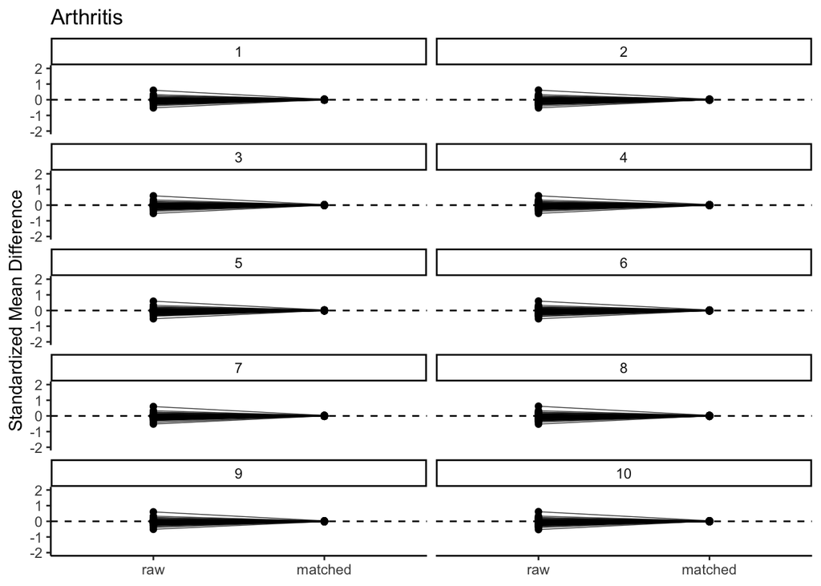

### Cancer

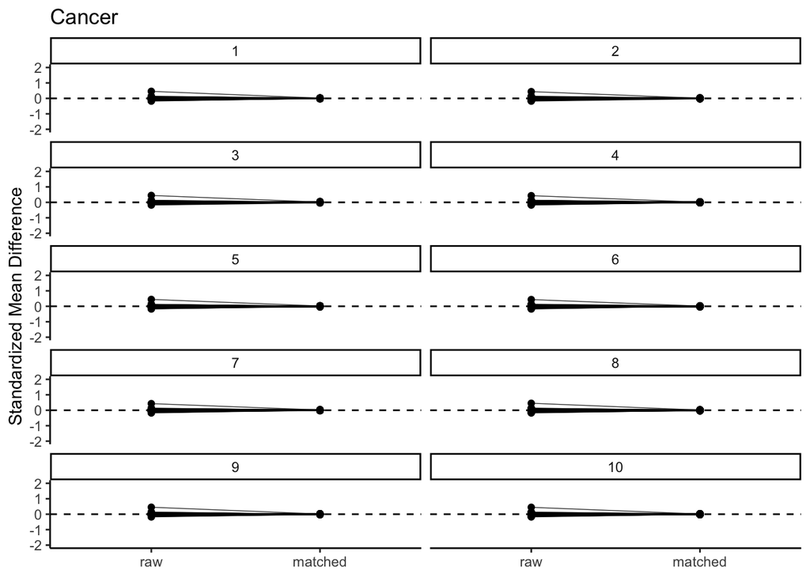

### Diabetes

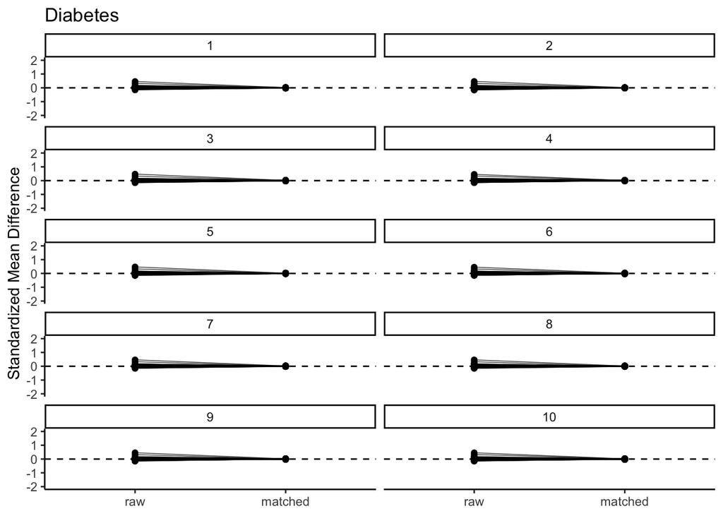

### HeartProb

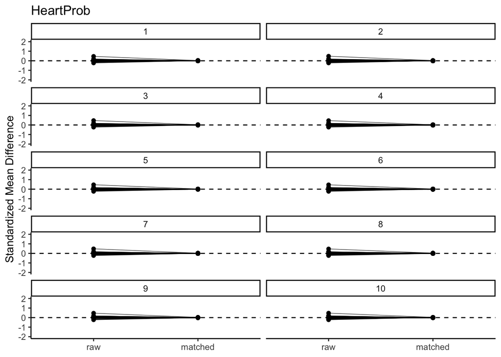

### HighBP

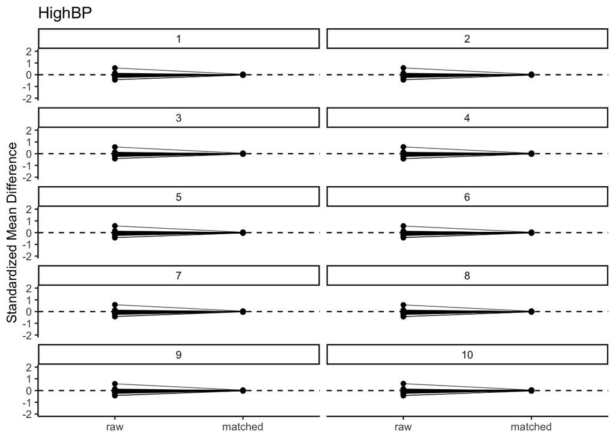

### LungDis

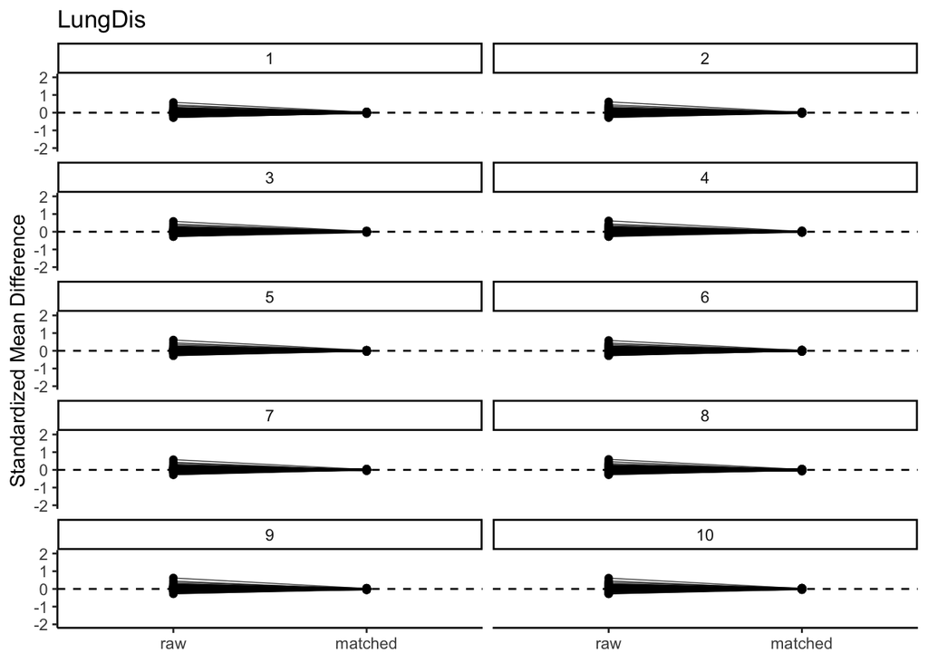

### Stroke

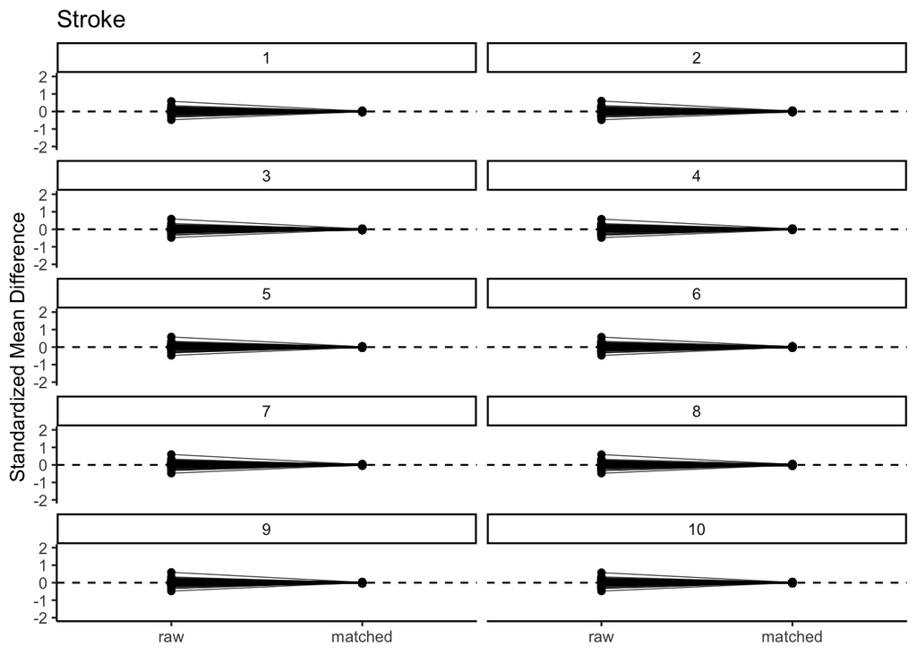